# R Notebook

```r
suppressPackageStartupMessages({
library(sf)
library(tmap)
library(dplyr)
library(tidyverse)
library(spatstat)
library(aspace)
library(units)
})
schools = st_read("C:/Users/USER/Desktop/Final exam/SCHOOL/SCHOOL.shp",options="ENCODING=BIG5")
```

```
## options:        ENCODING=BIG5
```

```r
taipei = st_read("C:/Users/USER/Desktop/Final exam/Taipei_Vill/Taipei_Vill.shp",options="ENCODING=BIG5")
```

```
## options:        ENCODING=BIG5
```

```r
fastfood = st_read("C:/Users/USER/Desktop/Final exam/Tpe_Fastfood/Tpe_Fastfood.shp",options="ENCODING=BIG5")
```

```
## options:        ENCODING=BIG5
```

```r
students = read.csv("C:/Users/USER/Desktop/Final exam/113_basec.csv",stringsAsFactors = FALSE)
```

```r
students = students %>% mutate(Name = str_remove_all(學校名稱, "^(私立|市立)")) %>% select(Name, TOTAL)

schools <- left_join(schools, students, by = "Name")
```

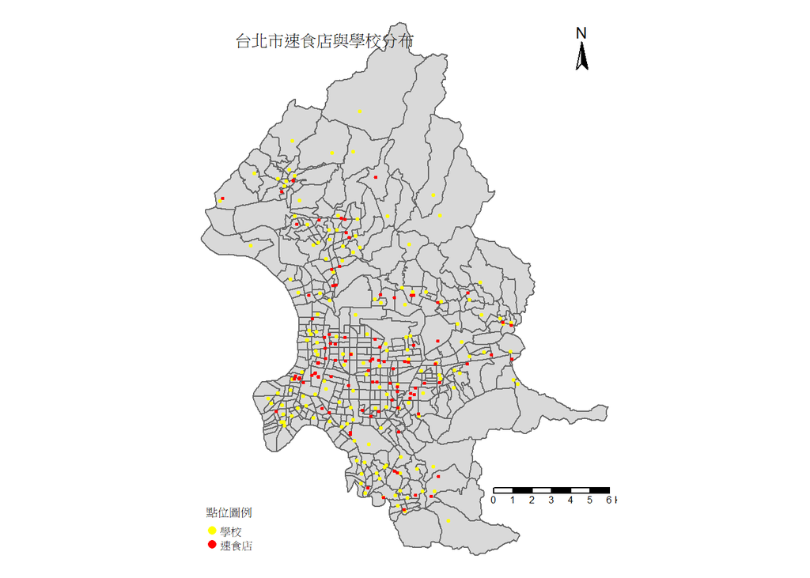

```r
schools_lyr = tm_shape(schools) + tm_dots(col = "yellow", size = 0.05)

fastfood_lyr = tm_shape(fastfood) + tm_dots(col = "red", size = 0.03)

taipei_lyr = tm_shape(taipei) +tm_polygons()

school_ff_lyr =
taipei_lyr + schools_lyr + fastfood_lyr +
  tm_layout(
    title = "台北市速食店與學校分布",
    title.position = c(0.1, 0.95),
    title.size = 0.8,
    legend.position = c("left", "bottom"),
    legend.title.size = 0.8,
    legend.text.size = 0.6,
    frame = FALSE
  ) +
  tm_scale_bar(position = c(0.7, 0.1), text.size = 0.5) +
  tm_compass(position = c("right", "top"), size = 1.5)+
  tm_add_legend(type = "symbol",
                labels = c("學校", "速食店"),
                col = c("yellow", "red"),
                shape = c(16, 16),
                size = 0.5,
                title = "點位圖例")

school_ff_lyr
```

```r
tmap_save(school_ff_lyr, filename = "school_ff_lyr.jpg", width = 2000, height = 1600, dpi = 300)
```

```
## Map saved to C:\Users\USER\Desktop\school_ff_lyr.jpg
```

```
## Resolution: 2000 by 1600 pixels
```

```
## Size: 6.666667 by 5.333333 inches (300 dpi)
```

### 學校500公尺半徑內的速食店數量

衛福部推動「校園周邊健康飲食輔導示範計畫」，以示範校園周邊（距離學校500公尺以內）之餐飲業者為計畫對象，因此以500公尺作為buffer半徑。計算每間學校500公尺半徑內的速食店數量。(ff_count)

```r
st_crs(schools) = st_crs(fastfood)

school_buffer = st_buffer(schools,dist=500)
school_ff.inter = st_intersects(school_buffer, fastfood)
schools$ff_count = lengths(school_ff.inter)

school_buffer_lyr = tm_shape(school_buffer) + tm_borders(col = "lightblue")
```

```r
cor.test(schools$TOTAL, schools$ff_count)
```

```
##
##  Pearson's product-moment correlation
##
## data:  schools$TOTAL and schools$ff_count
## t = 3.0233, df = 127, p-value = 0.003025
## alternative hypothesis: true correlation is not equal to 0
## 95 percent confidence interval:
##  0.0903044 0.4134505
## sample estimates:
##       cor
## 0.2591141
```

根據 Pearson 相關分析結，學校總學生人數與其500公尺範圍內的速食店數量之間具有統計上顯著相關，這顯示學生人數多的學校附近，可能有較多的速食店。

### 每間學校被速食店服務範圍覆蓋次數

步行十分鐘的距離約為600到800公尺，因此以速食店的800公尺內距離作為服務範圍，分析每間學校被速食店服務範圍覆蓋次數(ff_cover_count)

```r
fastfood_buffer <- st_buffer(fastfood, dist = 800)
ff_school <- st_intersects(schools, fastfood_buffer)
schools$ff_cover_count <- lengths(ff_school)
```

### 學生的速食店可及性

每間學校 500m 半徑內的速食店數量除以學生總人數，得出「每位學生平均可分配到速食店數量」，該數值越大表示學生的速食店可及性高(ff_per_student)

```r
schools$ff_per_student = schools$ff_count / schools$TOTAL

top5_schools <- schools %>%arrange(desc(ff_per_student)) %>%slice(1:5) %>%select(Name, ff_count, TOTAL, ff_per_student)

print(top5_schools)
```

```
## Simple feature collection with 5 features and 4 fields
## Geometry type: POINT
## Dimension:     XY
## Bounding box:  xmin: 300815.7 ymin: 2770546 xmax: 304668.2 ymax: 2781199
## Projected CRS: TWD97 / TM2 zone 121
##       Name ff_count TOTAL ff_per_student                 geometry
## 1 忠孝國小        3   328    0.009146341 POINT (302458.4 2770546)
## 2 西門國小        4   572    0.006993007 POINT (300815.7 2770654)
## 3 懷生國小        2   311    0.006430868 POINT (304668.2 2770898)
## 4 福星國小        3   619    0.004846527 POINT (301315.7 2771005)
## 5 逸仙國小        2   428    0.004672897 POINT (300934.3 2781199)
```

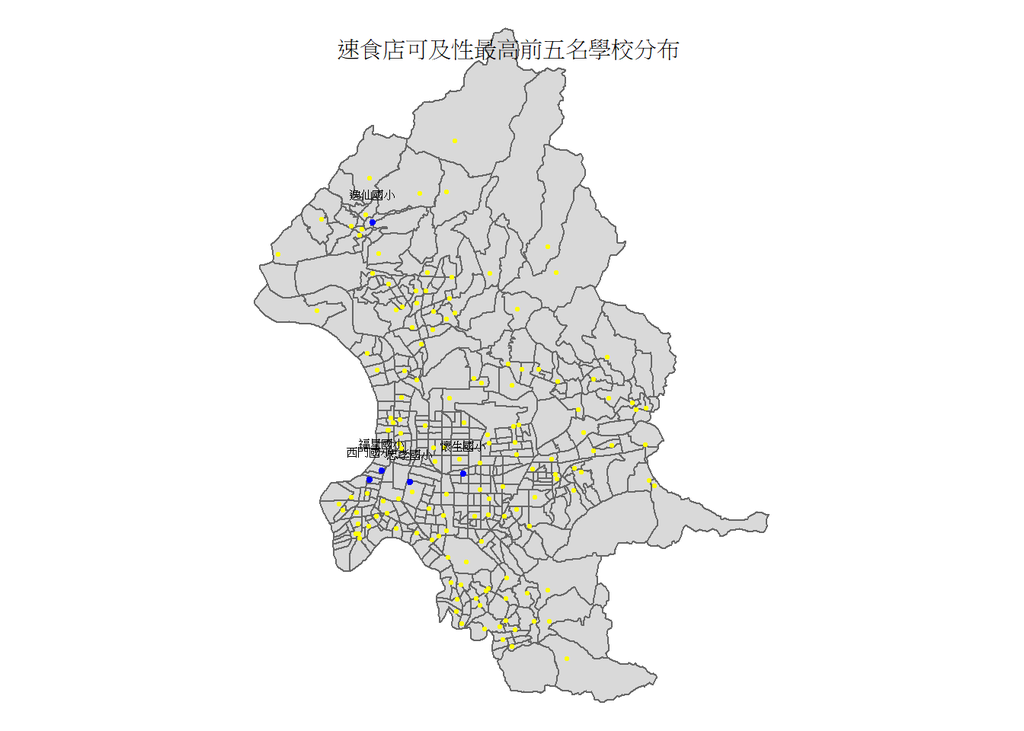

```r
top5_schools_geo <- schools[schools$Name %in% top5_schools$Name, ]

top5_schools_lyr <- tm_shape(top5_schools_geo) +
  tm_dots(col = "blue", size = 0.07, border.col = "black") + tm_text("Name", size = 0.5, ymod = 1)

school_access_lyr =
  taipei_lyr + schools_lyr + top5_schools_lyr +
  tm_layout(
    title = "速食店可及性最高前五名學校分布",
    title.position = c("center", "top"),
    title.size = 1,
    legend.outside = TRUE,
    frame = FALSE
  )

school_access_lyr
```

```r
tmap_save(school_access_lyr, filename = "school_access_lyr.jpg", width = 2000, height = 1600, dpi = 300)
```

```
## Map saved to C:\Users\USER\Desktop\school_access_lyr.jpg
```

```
## Resolution: 2000 by 1600 pixels
```

```
## Size: 6.666667 by 5.333333 inches (300 dpi)
```

### 台北市各行政區速食店面量圖

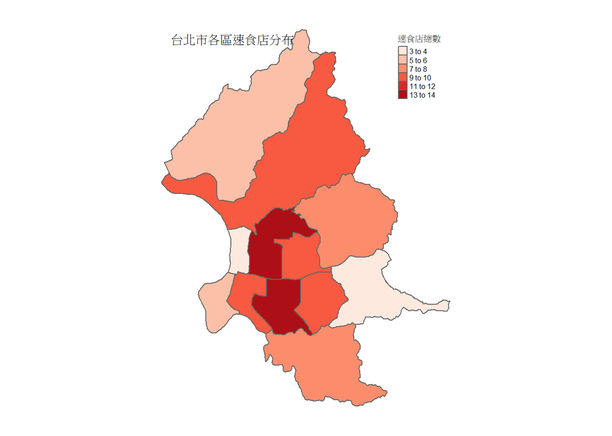

```r
taipei_town = taipei %>% group_by(TOWN) %>% summarise(geometry = st_union(geometry))

st_crs(fastfood) = st_crs(taipei_town)

town_ff = st_intersection(fastfood,taipei_town)
ff_count = town_ff %>%st_drop_geometry() %>% count(TOWN, name = "ff_count")

taipei_town = left_join(taipei_town, ff_count, by = "TOWN")

taipei_town_ff_lyr =
tm_shape(taipei_town) + tm_fill("ff_count", palette = "Reds", title = "速食店總數") + tm_borders() + tm_layout(outer.margins = c(0.05, 0.05, 0.05, 0.05),title="台北市各區速食店分布",title.position=c(0.05,"top"),title.size=0.8,legend.title.size = 0.8,legend.text.size = 0.5,frame=F)

taipei_town_ff_lyr
```

```r
tmap_save(taipei_town_ff_lyr, filename = "taipei_town_ff_lyr.jpg", width = 2000, height = 1600, dpi = 300)
```

```
## Map saved to C:\Users\USER\Desktop\taipei_town_ff_lyr.jpg
```

```
## Resolution: 2000 by 1600 pixels
```

```
## Size: 6.666667 by 5.333333 inches (300 dpi)
```

### 台北市行政區學生的速食店可及性

「每位學生平均可分配到速食店數量」在台北市各行政區的分布

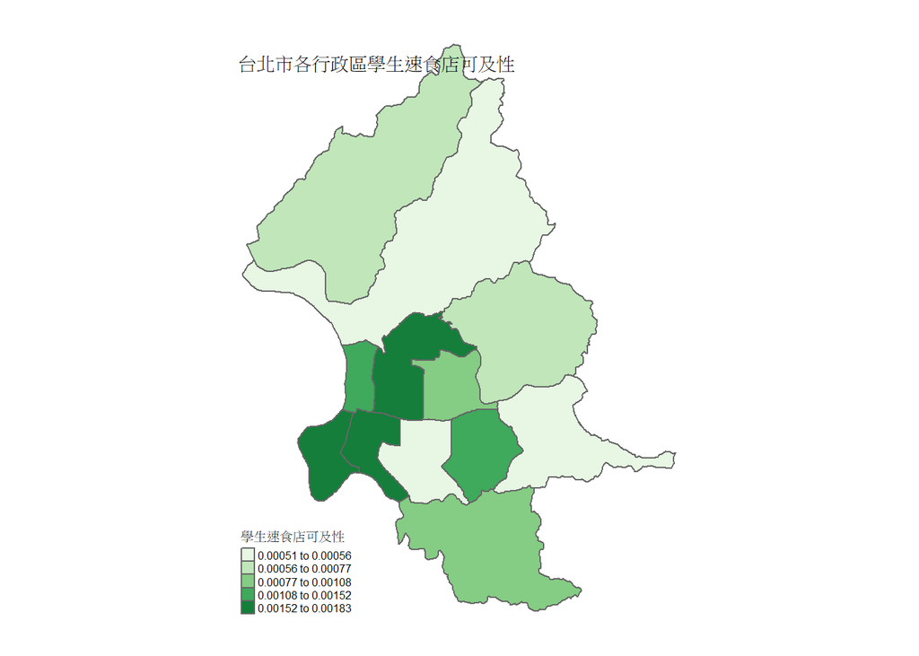

```r
schools_town <- st_join(schools, taipei_town, join = st_within)

town_access <- schools_town %>%
  st_drop_geometry() %>%
  group_by(TOWN) %>%
  summarise(avg_access = mean(ff_per_student, na.rm = TRUE))

taipei_town <- left_join(taipei_town, town_access, by = "TOWN")

town_ff_access_lyr =
tm_shape(taipei_town) +
  tm_fill("avg_access", palette = "Greens", style = "quantile", title = "學生速食店可及性") +
  tm_borders() +
  tm_layout(
    outer.margins = c(0.05, 0.05, 0.05, 0.05),
    title = "台北市各行政區學生速食店可及性",
    title.position = c(0.01, 0.95),
    title.size = 0.8,
    legend.title.size = 0.8,
    legend.text.size = 0.5,
    legend.position = c(0.01,0.01),
    frame = FALSE
  )
town_ff_access_lyr
```

```r
tmap_save(town_ff_access_lyr, filename = "town_ff_access_lyr.jpg", width = 2000, height = 1600, dpi = 300)
```

```
## Map saved to C:\Users\USER\Desktop\town_ff_access_lyr.jpg
```

```
## Resolution: 2000 by 1600 pixels
```

```
## Size: 6.666667 by 5.333333 inches (300 dpi)
```

### 每所學校距離最近速食店的距離。

```r
st_crs(schools) = st_crs(fastfood)

dist_matrix <- st_distance(schools, fastfood)
schools$nearest_ff_dist <- apply(dist_matrix, 1, min)
schools$nearest_ff_id <- apply(dist_matrix, 1, which.min)
schools$nearest_ff_name <- fastfood$ALIAS[schools$nearest_ff_id]
```

離速食店最近的五間學校

```r
nearest_top5 = schools %>%
  st_drop_geometry() %>%
  select(Name,nearest_ff_dist) %>%
  arrange(nearest_ff_dist) %>%
  slice(1:5)

nearest_top5
```

| Name | nearest_ff_dist |
| --- | --- |
| 永建國小 | 20.08037 |
| 長春國小 | 25.85447 |
| 三興國小 | 50.59599 |
| 松山國小 | 57.77174 |
| 南湖國小 | 82.78367 |

離速食店最遠的五間學校

```r
nearest_last5 = schools %>%
  st_drop_geometry() %>%
  arrange(desc(nearest_ff_dist)) %>%
  select(Name, nearest_ff_dist) %>%
  head(5)

nearest_last5
```

|  | Name | nearest_ff_dist |
| --- | --- | --- |
| 1 | 溪山國小 | 3906.909 |
| 2 | 湖田國小 | 3489.515 |
| 3 | 平等國小 | 3158.094 |
| 4 | 富安國小 | 2625.317 |
| 5 | 雙溪國小 | 2622.518 |

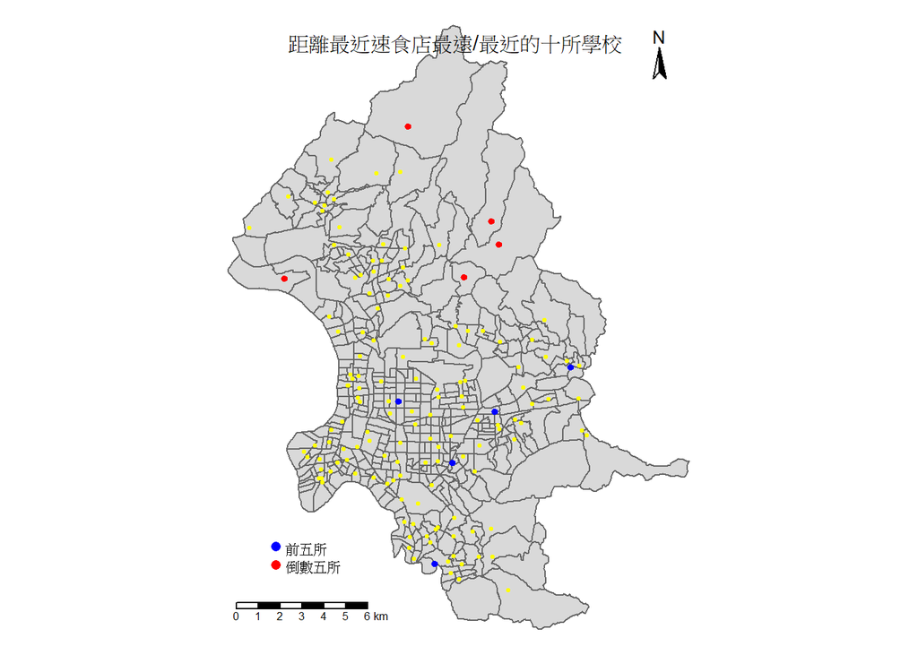

```r
nearest_top5_geo = schools[schools$Name %in% nearest_top5$Name, ]
nearest_last5_geo = schools[schools$Name %in% nearest_last5$Name, ]

top5_lyr = tm_shape(nearest_top5_geo) + tm_dots(col = "blue", size = 0.1, title = "最近速食店的前五所學校")
last5_lyr = tm_shape(nearest_last5_geo) + tm_dots(col = "red", size = 0.1, title = "最近速食店的倒數五所學校")

nearest_lyr =
taipei_lyr + schools_lyr + top5_lyr + last5_lyr  +
  tm_layout(
    title = "距離最近速食店最遠/最近的十所學校",
    title.position = c("center", "top"),
    title.size = 1,
    legend.position = c(0.1,0.1),
    frame = FALSE
  ) +
  tm_scale_bar(position = c("left", "bottom"), text.size = 0.5) +
  tm_compass(position = c("right", "top"), size = 1.5) +
  tm_add_legend(type = "symbol",
                labels = c("前五所", "倒數五所"),
                col = c("blue", "red"),
                shape = c(16, 16),
                size = 0.5,)

nearest_lyr
```

```r
tmap_save(nearest_lyr, filename = "nearest_lyr.jpg", width = 2000, height = 1600, dpi = 300)
```

```
## Map saved to C:\Users\USER\Desktop\nearest_lyr.jpg
```

```
## Resolution: 2000 by 1600 pixels
```

```
## Size: 6.666667 by 5.333333 inches (300 dpi)
```

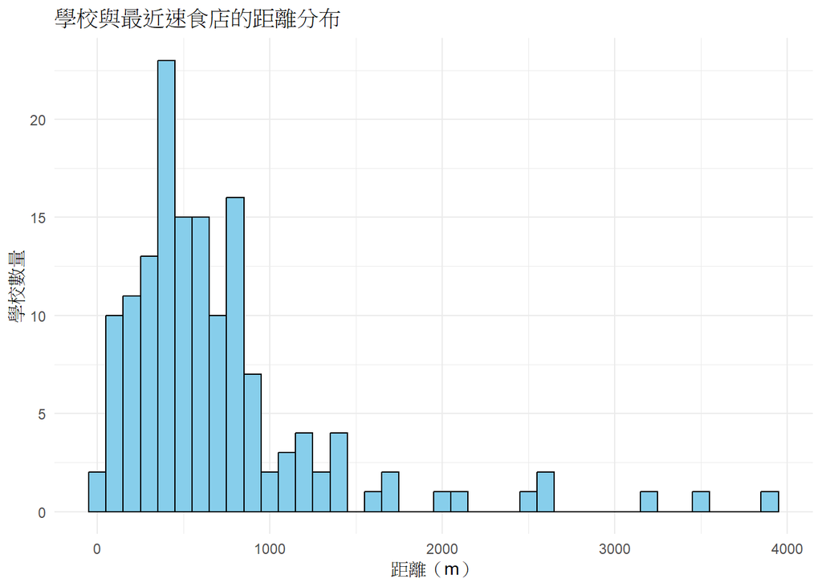

```r
ggplot(schools, aes(x = nearest_ff_dist)) +
  geom_histogram(binwidth = 100, fill = "skyblue", color = "black") +
  labs(title = "學校與最近速食店的距離分布",
       x = "距離（m）",
       y = "學校數量") +
  theme_minimal()
```

```r
ggsave("distance_histogram.jpg", width = 8, height = 6, dpi = 300)
```